# Practica2

Iosu Rodriguez

# 1. Descripción del dataset

### Carga del dataset

```r
# Cargamos el csv
data<-read.csv2('../data/StudentsPerformance.csv',header=T,sep=",")
# Mostramos los primeros registros
head(data)
```

```
##   gender race.ethnicity parental.level.of.education        lunch
## 1 female        group B           bachelor's degree     standard
## 2 female        group C                some college     standard
## 3 female        group B             master's degree     standard
## 4   male        group A          associate's degree free/reduced
## 5   male        group C                some college     standard
## 6 female        group B          associate's degree     standard
##   test.preparation.course math.score reading.score writing.score
## 1                    none         72            72            74
## 2               completed         69            90            88
## 3                    none         90            95            93
## 4                    none         47            57            44
## 5                    none         76            78            75
## 6                    none         71            83            78
```

### Tipo de campos

```r
# Mostramos el tipo de cada campo
sapply(data,class)
```

```
##                      gender              race.ethnicity
##                    "factor"                    "factor"
## parental.level.of.education                       lunch
##                    "factor"                    "factor"
##     test.preparation.course                  math.score
##                    "factor"                   "integer"
##               reading.score               writing.score
##                   "integer"                   "integer"
```

Los tipos asignados a cada campo se corresponden a los tipos reales.

### Descripción de los datos

```r
#Mostramos el resumen del dataset
summary(data)
```

```
##     gender    race.ethnicity     parental.level.of.education
##  female:518   group A: 89    associate's degree:222
##  male  :482   group B:190    bachelor's degree :118
##               group C:319    high school       :196
##               group D:262    master's degree   : 59
##               group E:140    some college      :226
##                              some high school  :179
##           lunch     test.preparation.course   math.score
##  free/reduced:355   completed:358           Min.   :  0.00
##  standard    :645   none     :642           1st Qu.: 57.00
##                                             Median : 66.00
##                                             Mean   : 66.09
##                                             3rd Qu.: 77.00
##                                             Max.   :100.00
##  reading.score    writing.score
##  Min.   : 17.00   Min.   : 10.00
##  1st Qu.: 59.00   1st Qu.: 57.75
##  Median : 70.00   Median : 69.00
##  Mean   : 69.17   Mean   : 68.05
##  3rd Qu.: 79.00   3rd Qu.: 79.00
##  Max.   :100.00   Max.   :100.00
```

Se observa que las variables no numéricas, son categóricas, de forma que más adelante podemos pensar en unificar aquellos valores que puedan representar lo mismo.

# 2. Integración y seleccion de los datos de interés a analizar

# 3. Limpieza de los datos

## 3.1.Valores nulos o ceros

```r
# Mostramos cuantos valores son nulos o 0
sapply(data, function(x) sum(is.na(x) || x == 0))
```

```
##                      gender              race.ethnicity
##                           0                           0
## parental.level.of.education                       lunch
##                           0                           0
##     test.preparation.course                  math.score
##                           0                           0
##               reading.score               writing.score
##                           0                           0
```

## 3.2.Valores extremos o outliers

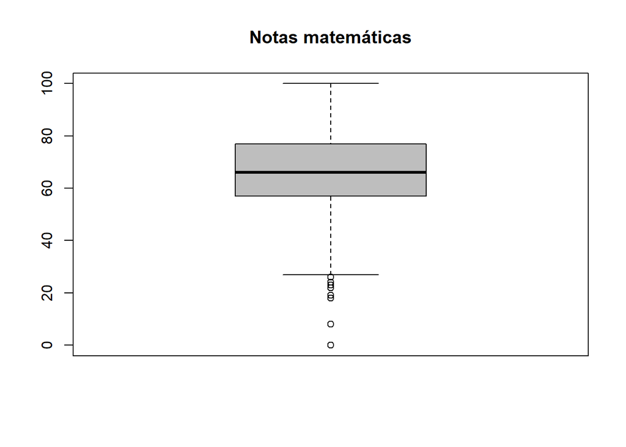

```r
# Mostramos un boxplot de cada variable numérica para observar si hay valores extremos.
boxplot(data$math.score,main="Notas matemáticas",col="gray")
```

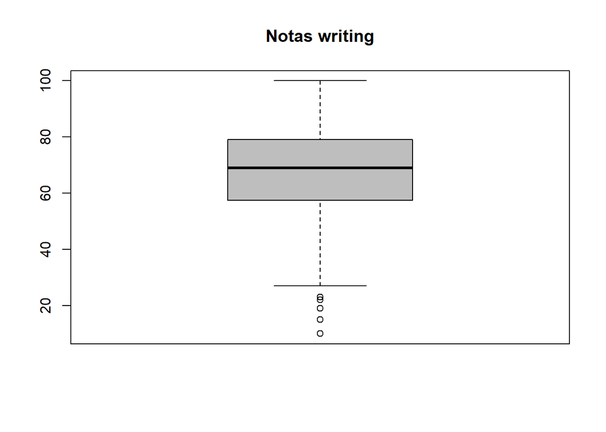

```r
boxplot(data$writing.score,main="Notas writing",col="gray")
```

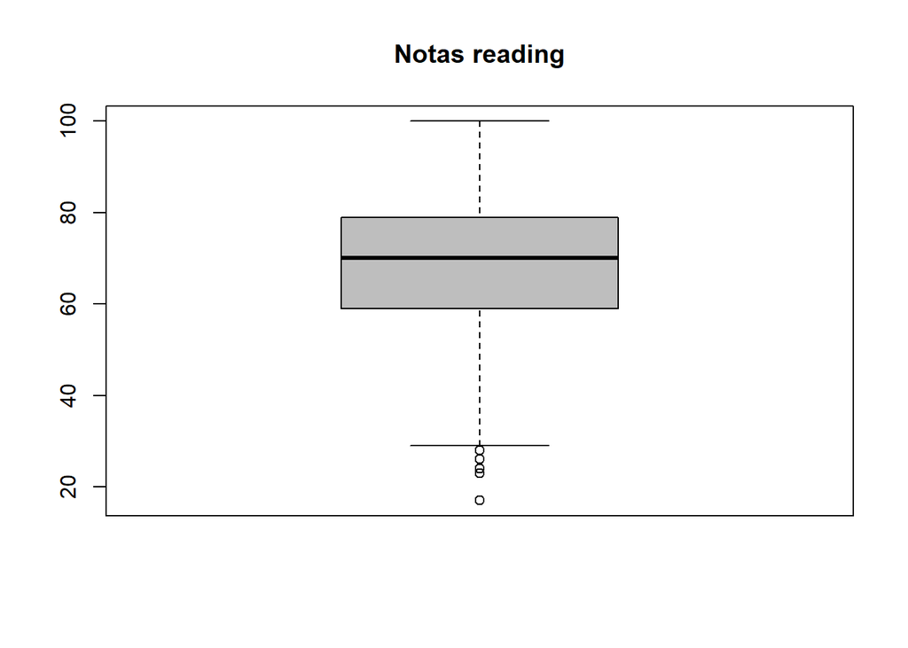

```r
boxplot(data$reading.score,main="Notas reading",col="gray")
```

Se observan varios valores extremos por debajo en las tres asignaturas. Sin embargo no nos preocupa. Se deben a alumnos que han sacado una nota muy baja, pero ya que no hay notas que superen la máxima posible (100) o sean menor que la mínima posible (<0), los mantenemos.

# 4.Análisis de los datos

## 4.1. Selección de los grupos de datos a analizar

Además de los datos que disponemos, queremos añadir dos nuevos campos. Uno para indicar la media de las tres asignautras de cada alumno y otro para indicar si con su media supera el aprobado o no. Se considera aprobado, una nota media igual o mayor a 50.

También vamos a unificar los niveles de estudio de los padres en 2. Aquellos con estudios universitarios (university) y aquellos que no (no_university). Se considera que no tienen estudios universitarios aquellos con valor ‘high school’, ‘some high school’

```r
# Añadimos la variable media
data$mean.score = as.numeric((data$math.score + data$reading.score + data$writing.score)/3)
# Añadimos la variable aprobado
data$aprobado = as.integer(data$mean.score >=50)

#Unificamos los niveles de educación de los padres
data$parental.level.of.education = as.factor(gsub("high school|some high school", "no_university",data$parental.level.of.education, ignore.case = TRUE))
data$parental.level.of.education<-as.character(data$parental.level.of.education)
data$parental.level.of.education = as.factor(replace(data$parental.level.of.education, data$parental.level.of.education != "no_university", "university"))

summary(data$parental.level.of.education)
```

```
## no_university    university
##           375           625
```

```r
sapply(data,class)
```

```
##                      gender              race.ethnicity
##                    "factor"                    "factor"
## parental.level.of.education                       lunch
##                    "factor"                    "factor"
##     test.preparation.course                  math.score
##                    "factor"                   "integer"
##               reading.score               writing.score
##                   "integer"                   "integer"
##                  mean.score                    aprobado
##                   "numeric"                   "integer"
```

## 4.2. Comprobación de la normalidad y homogeneidad de la varianza

### Normalización de los datos

Vamos a aplicar el test de Shapiro Wilk en cada variable numérica para ver si está normalizada.

```r
shapiro.test(data$math.score)
```

```
##
##  Shapiro-Wilk normality test
##
## data:  data$math.score
## W = 0.99315, p-value = 0.0001455
```

```r
shapiro.test(data$reading.score)
```

```
##
##  Shapiro-Wilk normality test
##
## data:  data$reading.score
## W = 0.99292, p-value = 0.0001055
```

```r
shapiro.test(data$writing.score)
```

```
##
##  Shapiro-Wilk normality test
##
## data:  data$writing.score
## W = 0.99196, p-value = 2.922e-05
```

```r
shapiro.test(data$mean.score)
```

```
##
##  Shapiro-Wilk normality test
##
## data:  data$mean.score
## W = 0.99315, p-value = 0.0001453
```

```r
max = 100
data$math.score = as.numeric(data$math.score/max)
data$reading.score = as.numeric(data$reading.score/max)
data$writing.score = as.numeric(data$writing.score/max)
data$mean.score = as.numeric(round(data$mean.score/max, 2))
```

### Guardamos el dataset limpio y con los nuevos datos

```r
write.csv(data, "../data/StudentsPerformance_clean.csv")
```

## 4.3. Aplicación de pruebas estadísticas

### 4.3.1.¿Qué factores influyen más a la hora de que un alumno saque mejores notas?

Para responder a esta pregunta vamos a observar la relación entre la nota media y cada variable categórica.

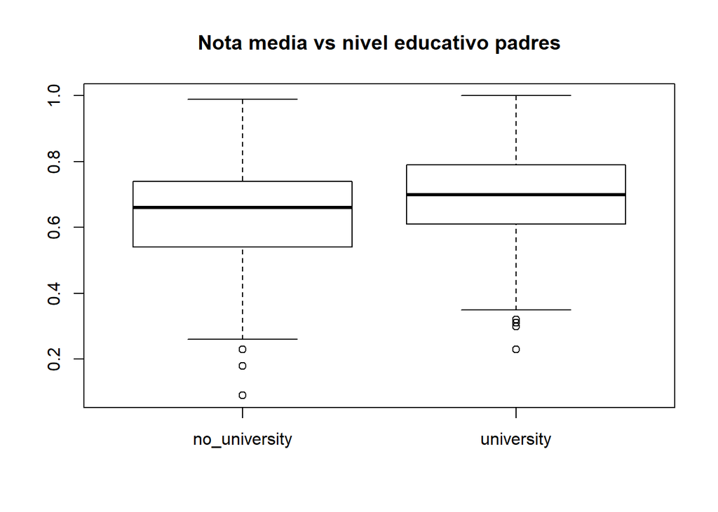

```r
boxplot(data$mean.score ~ data$parental.level.of.education,main="Nota media vs nivel educativo padres")
```

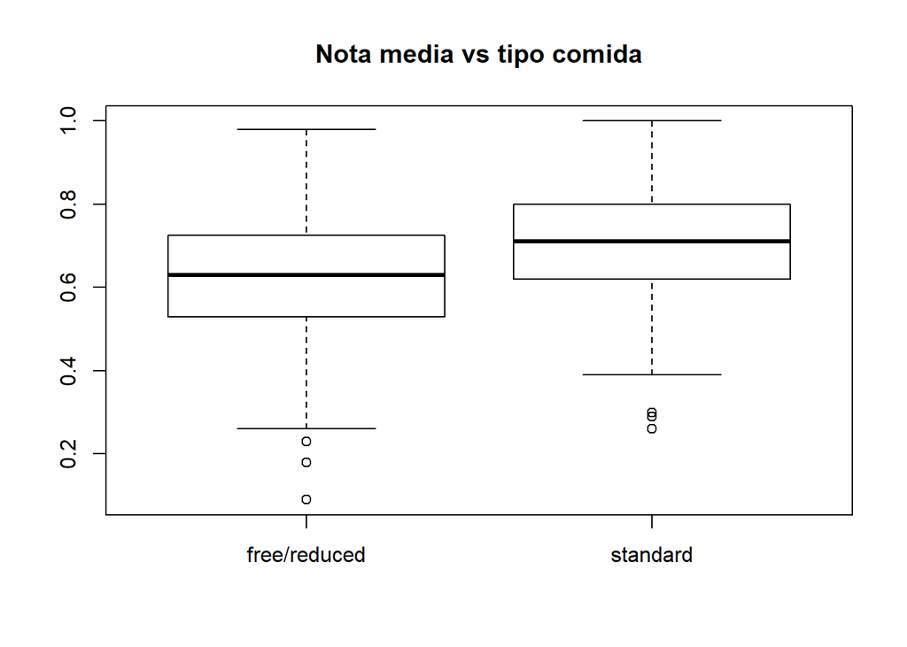

```r
boxplot(data$mean.score ~ data$lunch,main="Nota media vs tipo comida")
```

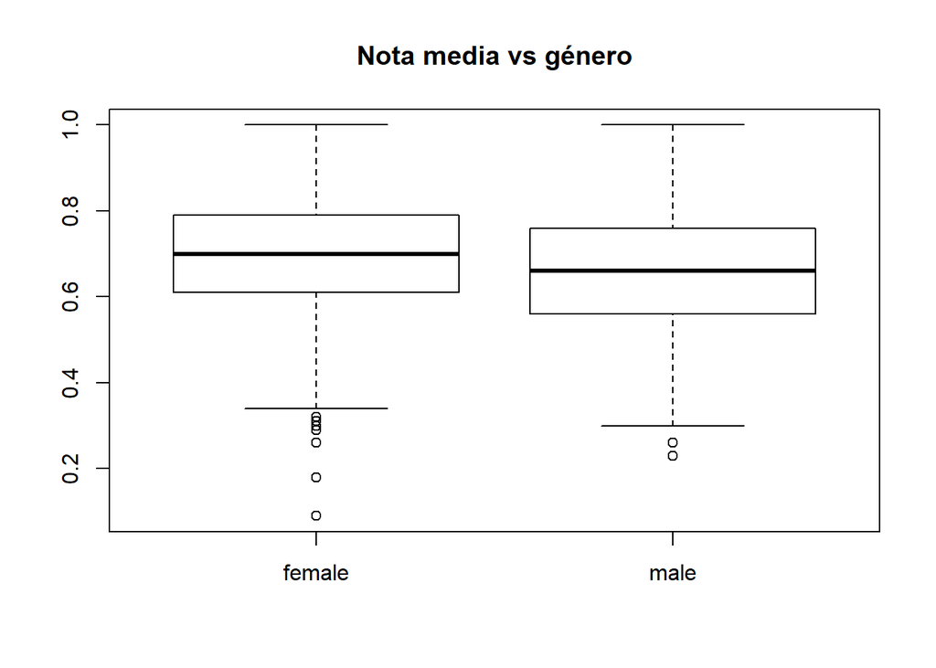

```r
boxplot(data$mean.score ~ data$gender,main="Nota media vs género")
```

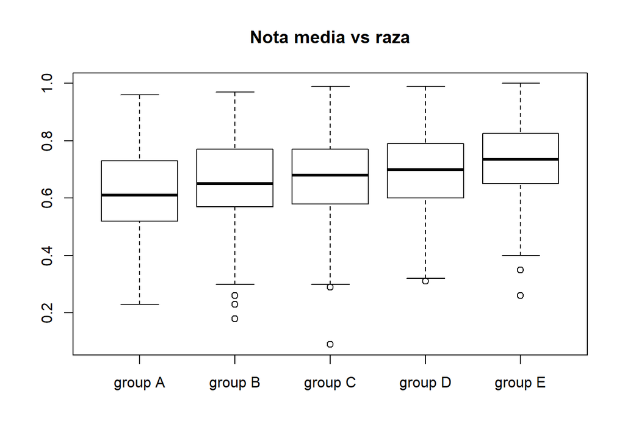

```r
boxplot(data$mean.score ~ data$race.ethnicity,main="Nota media vs raza")
```

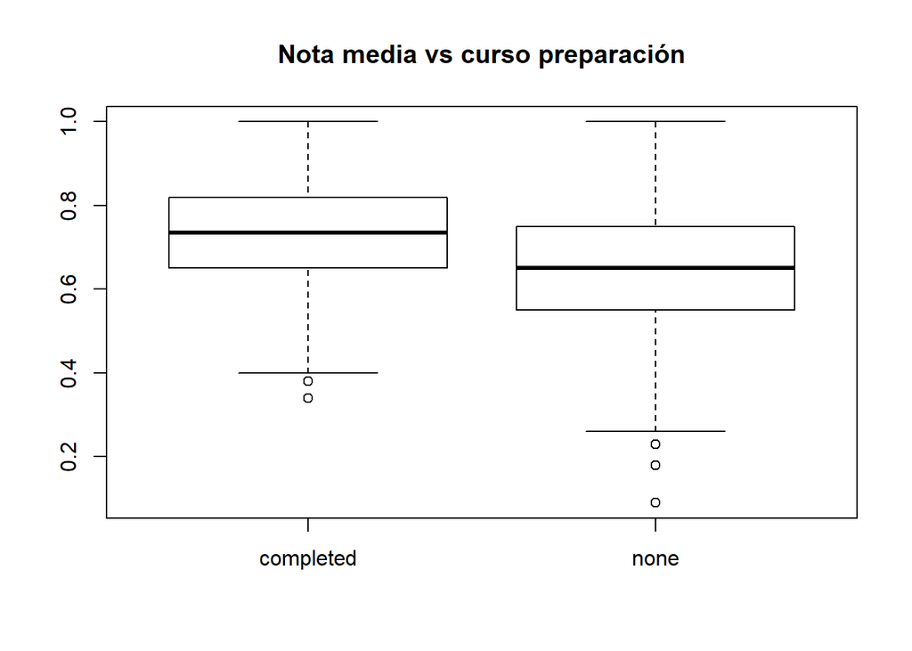

```r
boxplot(data$mean.score ~ data$test.preparation.course,main="Nota media vs curso preparación")
```

### 4.3.2.¿En que asignaturas son mejores los hombres y en cuales las mujeres?

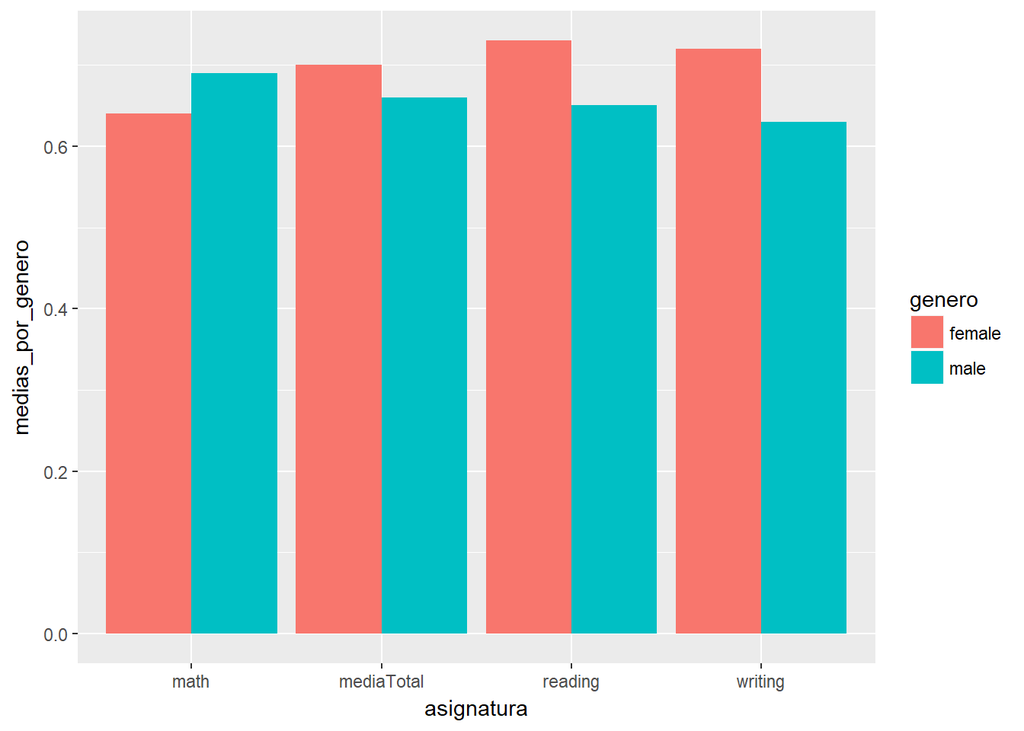

```r
medias_por_genero = c(
  as.numeric(round(mean(data$math.score[data$gender=='female']),2)),
  as.numeric(round(mean(data$math.score[data$gender=='male']),2)),
  as.numeric(round(mean(data$reading.score[data$gender=='female']),2)),
  as.numeric(round(mean(data$reading.score[data$gender=='male']),2)),
  as.numeric(round(mean(data$writing.score[data$gender=='female']),2)),
  as.numeric(round(mean(data$writing.score[data$gender=='male']),2)),
  as.numeric(round(mean(data$mean.score[data$gender=='female']),2)),
  as.numeric(round(mean(data$mean.score[data$gender=='male']),2))
)
genero = c(rep(c('female','male'),4))
asignatura = c(rep('math',2),rep('reading',2),rep('writing',2),rep('mediaTotal',2))
dataMediasGenero=data.frame(medias_por_genero,genero,asignatura)

ggplot(dataMediasGenero, aes(fill=genero, y=medias_por_genero, x=asignatura)) +
    geom_bar(position="dodge", stat="identity")
```

Podemos asegurar que las mujeres han obtenido mejor media. Que los hombres han sacado mejor nota media en matemáticas y las mujeres en lectura y escritura.

### 4.3.3.¿La nota media de los alumnos es mayor para aquellos con padres con estudios universitarios?

Planteamos las hipótesis: -Hipótesis nula: H0: mu1-mu2=0. La nota media es la misma tanto si los padres tienen estudios universitarios (mu1) como si no (m2).

-Hipótesis alternativa: H1: mu1-mu2>0 la nota media es superior si los padres tienen estudios universitarios.

```r
padresuniv.si<-data[ data$parental.level.of.education == 'university', ]
padresuniv.no<-data[ data$parental.level.of.education == 'no_university', ]
t.test(padresuniv.si$mean.score, padresuniv.no$mean.score, alternative="greater", conf.level=0.99, paired=FALSE, var.equal=FALSE)
```

```
##
##  Welch Two Sample t-test
##
## data:  padresuniv.si$mean.score and padresuniv.no$mean.score
## t = 6.4502, df = 767.89, p-value = 9.878e-11
## alternative hypothesis: true difference in means is greater than 0
## 99 percent confidence interval:
##  0.03789259        Inf
## sample estimates:
## mean of x mean of y
## 0.6998720 0.6405333
```

Puesto que el p-valor es 9.878e-11 < 0.01, rechazamos la hipótesis nula y aceptamos la hipótesis alternativa. Por tanto podemos decir con un 99% de confianza que la nota media de los alumnos es mayor en aquellos que tienen padres universitarios.

### 4.3.4.¿Podríamos saber a partir de los datos de los alumnos, antes de realizar los exámenes, que previsión hay de aprobados y suspensos en función de sus datos?

Vamos a aplicar la regresión logística considerando como variables todos los factores. De esta forma crearemos un modelo para clasificar a los alumnos como aprobados o suspendidos en función de sus datos.

```r
model = glm(data$aprobado~data$gender+data$parental.level.of.education+data$lunch+data$race.ethnicity+data$test.preparation.course, family=binomial(link='logit'))
summary(model)
```

```
##
## Call:
## glm(formula = data$aprobado ~ data$gender + data$parental.level.of.education +
##     data$lunch + data$race.ethnicity + data$test.preparation.course,
##     family = binomial(link = "logit"))
##
## Deviance Residuals:
##     Min       1Q   Median       3Q      Max
## -2.6879   0.2143   0.3233   0.4788   1.2304
##
## Coefficients:
##                                            Estimate Std. Error z value
## (Intercept)                                 1.75615    0.41818   4.200
## data$gendermale                            -0.72332    0.22731  -3.182
## data$parental.level.of.educationuniversity  1.06968    0.22416   4.772
## data$lunchstandard                          1.20540    0.22414   5.378
## data$race.ethnicitygroup B                  0.05033    0.37239   0.135
## data$race.ethnicitygroup C                  0.43921    0.35806   1.227
## data$race.ethnicitygroup D                  0.88752    0.38800   2.287
## data$race.ethnicitygroup E                  0.71055    0.46626   1.524
## data$test.preparation.coursenone           -1.15659    0.27799  -4.161
##                                            Pr(>|z|)
## (Intercept)                                2.67e-05 ***
## data$gendermale                             0.00146 **
## data$parental.level.of.educationuniversity 1.82e-06 ***
## data$lunchstandard                         7.54e-08 ***
## data$race.ethnicitygroup B                  0.89248
## data$race.ethnicitygroup C                  0.21996
## data$race.ethnicitygroup D                  0.02217 *
## data$race.ethnicitygroup E                  0.12753
## data$test.preparation.coursenone           3.17e-05 ***
## ---
## Signif. codes:  0 '***' 0.001 '**' 0.01 '*' 0.05 '.' 0.1 ' ' 1
##
## (Dispersion parameter for binomial family taken to be 1)
##
##     Null deviance: 663.25  on 999  degrees of freedom
## Residual deviance: 571.31  on 991  degrees of freedom
## AIC: 589.31
##
## Number of Fisher Scoring iterations: 6
```

Observamos que el modelo obtenido no es demasiado bueno. Posiblemente necesitemos más datos, o simplemente, clasificar a los alumnos por sus factores como posibles aprobados o suspendidos, no es factible, ya que las posibles combinaciones de los valores que toman los factores es limitada. Veremos con este modelo cuantos acertamos y fallamos.

```r
prob_acc <-predict(model,data, type = "response")
pred_acc <-ifelse (prob_acc>= 0.5, 1, 0)
table(data$aprobado,pred_acc)
```

```
##    pred_acc
##       0   1
##   0   8  95
##   1   6 891
```

Con este modelo vemos que somo muy optimistas, dando por aprobados a la gran mayoría de suspendidos. Sin embargo, si predecimos bien aquellos que han aprobado.

Ahora vamos a ver si conseguimos un modelo que sirva para predecir los aprobados y suspensos de cada asignatura en función de los factores

```r
accMath = as.integer(data$math.score >=0.5)
accReading = as.integer(data$reading.score >=0.5)
accWriting = as.integer(data$writing.score >=0.5)

modelMath = glm(accMath~data$gender+data$parental.level.of.education+data$lunch+data$race.ethnicity+data$test.preparation.course, family=binomial(link='logit'))
summary(modelMath )
```

```
##
## Call:
## glm(formula = accMath ~ data$gender + data$parental.level.of.education +
##     data$lunch + data$race.ethnicity + data$test.preparation.course,
##     family = binomial(link = "logit"))
##
## Deviance Residuals:
##     Min       1Q   Median       3Q      Max
## -2.6254   0.2219   0.3471   0.5210   1.4046
##
## Coefficients:
##                                            Estimate Std. Error z value
## (Intercept)                                  0.4598     0.3741   1.229
## data$gendermale                              0.6349     0.2078   3.055
## data$parental.level.of.educationuniversity   0.7015     0.2028   3.458
## data$lunchstandard                           1.8300     0.2113   8.659
## data$race.ethnicitygroup B                   0.2836     0.3581   0.792
## data$race.ethnicitygroup C                   0.4664     0.3383   1.379
## data$race.ethnicitygroup D                   0.7675     0.3569   2.150
## data$race.ethnicitygroup E                   1.0840     0.4549   2.383
## data$test.preparation.coursenone            -0.9796     0.2377  -4.121
##                                            Pr(>|z|)
## (Intercept)                                0.219073
## data$gendermale                            0.002250 **
## data$parental.level.of.educationuniversity 0.000544 ***
## data$lunchstandard                          < 2e-16 ***
## data$race.ethnicitygroup B                 0.428499
## data$race.ethnicitygroup C                 0.168002
## data$race.ethnicitygroup D                 0.031522 *
## data$race.ethnicitygroup E                 0.017169 *
## data$test.preparation.coursenone           3.77e-05 ***
## ---
## Signif. codes:  0 '***' 0.001 '**' 0.01 '*' 0.05 '.' 0.1 ' ' 1
##
## (Dispersion parameter for binomial family taken to be 1)
##
##     Null deviance: 791.56  on 999  degrees of freedom
## Residual deviance: 657.76  on 991  degrees of freedom
## AIC: 675.76
##
## Number of Fisher Scoring iterations: 5
```

```r
modelReading = glm(accReading~data$gender+data$parental.level.of.education+data$lunch+data$race.ethnicity+data$test.preparation.course, family=binomial(link='logit'))
summary(modelReading)
```

```
##
## Call:
## glm(formula = accReading ~ data$gender + data$parental.level.of.education +
##     data$lunch + data$race.ethnicity + data$test.preparation.course,
##     family = binomial(link = "logit"))
##
## Deviance Residuals:
##     Min       1Q   Median       3Q      Max
## -2.7111   0.2234   0.3339   0.4825   1.1341
##
## Coefficients:
##                                            Estimate Std. Error z value
## (Intercept)                                  2.1518     0.4394   4.897
## data$gendermale                             -0.9579     0.2447  -3.915
## data$parental.level.of.educationuniversity   0.7563     0.2327   3.249
## data$lunchstandard                           1.0419     0.2336   4.460
## data$race.ethnicitygroup B                   0.1587     0.3820   0.415
## data$race.ethnicitygroup C                   0.6431     0.3714   1.732
## data$race.ethnicitygroup D                   0.8197     0.3894   2.105
## data$race.ethnicitygroup E                   0.7904     0.4813   1.642
## data$test.preparation.coursenone            -1.0910     0.2917  -3.740
##                                            Pr(>|z|)
## (Intercept)                                9.71e-07 ***
## data$gendermale                            9.04e-05 ***
## data$parental.level.of.educationuniversity 0.001157 **
## data$lunchstandard                         8.22e-06 ***
## data$race.ethnicitygroup B                 0.677869
## data$race.ethnicitygroup C                 0.083328 .
## data$race.ethnicitygroup D                 0.035293 *
## data$race.ethnicitygroup E                 0.100505
## data$test.preparation.coursenone           0.000184 ***
## ---
## Signif. codes:  0 '***' 0.001 '**' 0.01 '*' 0.05 '.' 0.1 ' ' 1
##
## (Dispersion parameter for binomial family taken to be 1)
##
##     Null deviance: 605.08  on 999  degrees of freedom
## Residual deviance: 533.88  on 991  degrees of freedom
## AIC: 551.88
##
## Number of Fisher Scoring iterations: 6
```

```r
modelWriting = glm(accWriting~data$gender+data$parental.level.of.education+data$lunch+data$race.ethnicity+data$test.preparation.course, family=binomial(link='logit'))
summary(modelWriting)
```

```
##
## Call:
## glm(formula = accWriting ~ data$gender + data$parental.level.of.education +
##     data$lunch + data$race.ethnicity + data$test.preparation.course,
##     family = binomial(link = "logit"))
##
## Deviance Residuals:
##     Min       1Q   Median       3Q      Max
## -2.6634   0.2000   0.3475   0.4971   1.4145
##
## Coefficients:
##                                            Estimate Std. Error z value
## (Intercept)                                  2.2529     0.4231   5.324
## data$gendermale                             -1.3061     0.2342  -5.576
## data$parental.level.of.educationuniversity   0.9422     0.2165   4.351
## data$lunchstandard                           0.9869     0.2171   4.545
## data$race.ethnicitygroup B                   0.2778     0.3580   0.776
## data$race.ethnicitygroup C                   0.7393     0.3443   2.147
## data$race.ethnicitygroup D                   1.0261     0.3639   2.820
## data$race.ethnicitygroup E                   0.7839     0.4327   1.811
## data$test.preparation.coursenone            -1.4888     0.2892  -5.148
##                                            Pr(>|z|)
## (Intercept)                                1.01e-07 ***
## data$gendermale                            2.46e-08 ***
## data$parental.level.of.educationuniversity 1.35e-05 ***
## data$lunchstandard                         5.49e-06 ***
## data$race.ethnicitygroup B                  0.43774
## data$race.ethnicitygroup C                  0.03179 *
## data$race.ethnicitygroup D                  0.00481 **
## data$race.ethnicitygroup E                  0.07007 .
## data$test.preparation.coursenone           2.63e-07 ***
## ---
## Signif. codes:  0 '***' 0.001 '**' 0.01 '*' 0.05 '.' 0.1 ' ' 1
##
## (Dispersion parameter for binomial family taken to be 1)
##
##     Null deviance: 709.59  on 999  degrees of freedom
## Residual deviance: 593.38  on 991  degrees of freedom
## AIC: 611.38
##
## Number of Fisher Scoring iterations: 6
```

```r
print('Predicciones para matemáticas')
```

```
## [1] "Predicciones para matemáticas"
```

```r
prob_acc <-predict(modelMath,data, type = "response")
pred_acc <-ifelse (prob_acc>= 0.5, 1, 0)
table(accMath,pred_acc)
```

```
##        pred_acc
## accMath   0   1
##       0  21 114
##       1  11 854
```

```r
print('Predicciones para reading')
```

```
## [1] "Predicciones para reading"
```

```r
prob_acc <-predict(modelReading,data, type = "response")
pred_acc <-ifelse (prob_acc>= 0.5, 1, 0)
table(accReading,pred_acc)
```

```
##           pred_acc
## accReading   1
##          0  90
##          1 910
```

```r
print('Predicciones para writing')
```

```
## [1] "Predicciones para writing"
```

```r
prob_acc <-predict(modelWriting,data, type = "response")
pred_acc <-ifelse (prob_acc>= 0.5, 1, 0)
table(accWriting,pred_acc)
```

```
##           pred_acc
## accWriting   0   1
##          0  10 104
##          1   4 882
```

Como observamos seguimos sin poder obtener un modelo bueno para poder clasificar con cierta seguridad los aprobados y suspensos a partir de los datos de los alumnos, antes de que realicen los exámenes. Concluimos que con los factores de los alumnos no somo capaces de clasificar a estos como candidatos a aprobar o suspender.